# R Lab 8 - KEY

Prof. Amanda D. Perez, PhD

# Bootstrapping the Mean IMDB Rating

We will be using data from The Office.

Specifically, we will use `theoffice` data from the [**schrute**](https://bradlindblad.github.io/schrute/) package to estimate mean IMDB scores for episodes of The Office.

First, let’s load our packages.

```r
library(tidyverse)
library(tidymodels)
library(schrute)
library(lubridate)
library(psych)
```

There are many things we can bootstrap but the goal for this first exercise will be to bootstrap the mean `imdb_rating`.

Below are the steps for bootstrapping:

1. Take a bootstrap sample - a random sample taken with replacement from the original sample, of the same size as the original sample
2. Calculate the bootstrap statistic - a statistic such as mean, median, proportion, slope, etc. computed on the bootstrap samples
3. Repeat steps (1) and (2) many times to create a bootstrap distribution - a distribution of bootstrap statistics
4. Calculate the bounds of the XX% confidence interval as the middle XX% of the bootstrap distribution

## Exercise 1

Fill in the blanks below to successfully create `office_boot`. You will need to take the `theoffice` dataset, specify `imdb_rating` as the response, generate `100` samples, and calculate the `mean`.

```r
set.seed(8888)
# save resulting bootstrap distribution
office_boot <- theoffice %>%
  # specify the variable of interest
  specify(response = imdb_rating) %>%
  # generate 100 bootstrap samples
  generate(reps = 100, type = "bootstrap") %>%
  # calculate the mean of each bootstrap sample
  calculate(stat = "mean")
```

## Exercise 2

How many observations are there in `office_boot`? What does each observation represent?

```r
glimpse(office_boot)
```

```
## Rows: 100
## Columns: 2
## $ replicate <int> 1, 2, 3, 4, 5, 6, 7, 8, 9, 10, 11, 12, 13, 14, 15, 16, 17, 1…
## $ stat      <dbl> 8.299935, 8.305144, 8.308591, 8.299831, 8.301054, 8.301135, …
```

ANSWER: Each observation represents a bootsrapped mean

## Exercise 3

Visualize the bootstrap distribution. Below I have created a basic histogram. Your job is to: Add a theme, use both `color` and `fill` within the `geom_histogram()` function (see links for help), set the histogram `alpha = 0.5`, add a `geom_vline()` that has the value of the mean `office_boot$stat` and give it a `color` (see links below for help), Add a title, make the x axis say `Mean`, and finally make the y axis say `Frequency`.

[**Histogram Help**](http://www.sthda.com/english/wiki/ggplot2-histogram-plot-quick-start-guide-r-software-and-data-visualization#change-histogram-plot-line-types-and-colors)

[**Adding a Vertical Line Help**](https://www.rdocumentation.org/packages/ggplot2/versions/0.9.1/topics/geom_vline)

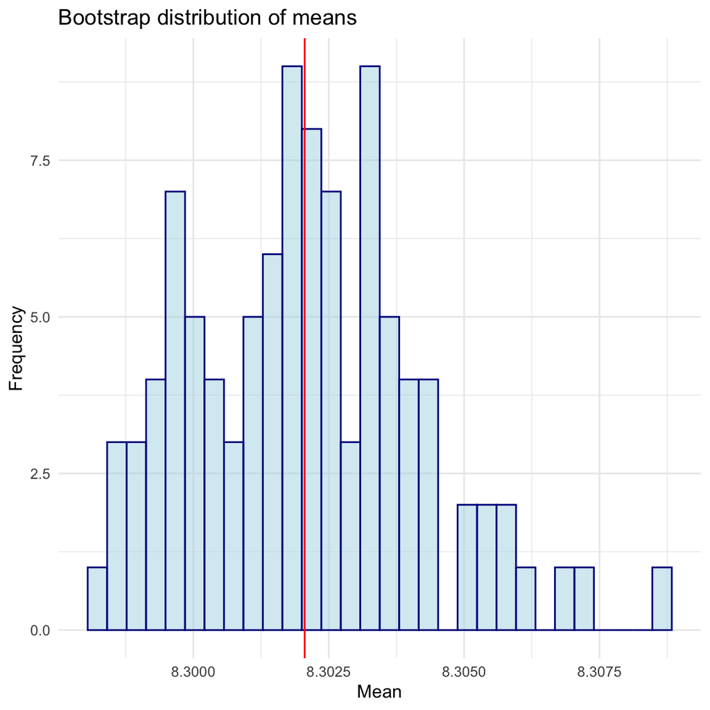

```r
ggplot(data = office_boot, mapping = aes(x = stat)) +
  geom_histogram(color="darkblue", fill="lightblue", alpha = 0.5) +
  geom_vline(xintercept = mean(office_boot$stat), color ="red")+
labs(title = "Bootstrap distribution of means", x = "Mean", y = "Frequency") +
  theme_minimal()
```

## Exercise 4

Calculate the confidence interval. A 95% confidence interval is bounded by the middle 95% of the bootstrap distribution. Fill in the values below.

```r
office_boot %>%
  summarize(lower = quantile(stat, 0.025),
            upper = quantile(stat, 0.975))
```

```
## # A tibble: 1 × 2
##   lower upper
##   <dbl> <dbl>
## 1  8.30  8.31
```

## Exercise 5

Copy and paste your histogram code from exercise 3. Your task is to add on an additional 2 lines, one for the lower 95% bound and one for the higher 95% bound. Make the line dashed *and* a different color than your line you already have for the mean.

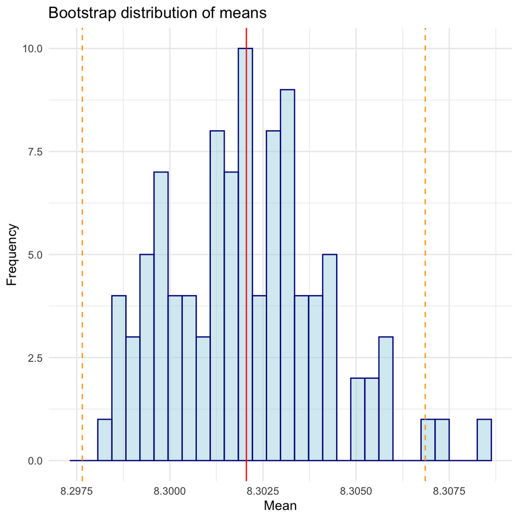

```r
ggplot(data = office_boot, mapping = aes(x = stat)) +
  geom_histogram(color="darkblue", fill="lightblue", alpha = 0.5) +
  geom_vline(xintercept = mean(office_boot$stat), color ="red") +
  geom_vline(xintercept = 8.297651, color ="orange", linetype = "dashed") +
  geom_vline(xintercept = 8.306856, color ="orange", linetype = "dashed") +
labs(title = "Bootstrap distribution of means", x = "Mean", y = "Frequency") +
  theme_minimal()
```

## Exercise 6

Your final task is to interpret what the 95% confidence bounds you calculated mean in the context of The Office’s IMDB Ratings.

# Bootstrapping a Slope

For the final set of exercises, we will again be using data from The Office.

This time, we are going to bootstrap a slope. Specifically, we will use `imdb_rating` as the DV and `season` as the IV.

## Exercise 7

Fill in the blanks below to successfully create `office_boot_slope`. You will need to take the `theoffice` dataset, specify `imdb_rating` as the response, specify `season` as the explanatory variable, generate `100` samples, and calculate the `slope`.

```r
set.seed(8888)
# save resulting bootstrap distribution
office_boot_slope <- theoffice %>%
  # specify the variable of interest
  specify(response = imdb_rating,
          explanatory = season) %>%
  # generate 100 bootstrap samples
  generate(reps = 100, type = "bootstrap") %>%
  # calculate the mean of each bootstrap sample
  calculate(stat = "slope")
```

## Exercise 8

How many observations are there in `office_boot`? What does each observation represent?

```r
glimpse(office_boot_slope)
```

```
## Rows: 100
## Columns: 2
## $ replicate <int> 1, 2, 3, 4, 5, 6, 7, 8, 9, 10, 11, 12, 13, 14, 15, 16, 17, 1…
## $ stat      <dbl> -0.08511394, -0.08406704, -0.08385859, -0.08657430, -0.08424…
```

ANSWER: Each observation represents a bootstrapped slope

## Exercise 9

Visualize the bootstrap distribution. Below I have created a basic histogram. Your job is to: Add a theme, use both `color` and `fill` within the `geom_histogram()` function (see links for help), set the histogram `alpha = 0.5`, add a `geom_vline()` that has the value of the slope `office_boot_slope$stat` and give it a `color` (see links below for help), Add a title, make the x axis say `Slope`, and finally make the y axis say `Frequency`.

[**Histogram Help**](http://www.sthda.com/english/wiki/ggplot2-histogram-plot-quick-start-guide-r-software-and-data-visualization#change-histogram-plot-line-types-and-colors)

[**Adding a Vertical Line Help**](https://www.rdocumentation.org/packages/ggplot2/versions/0.9.1/topics/geom_vline)

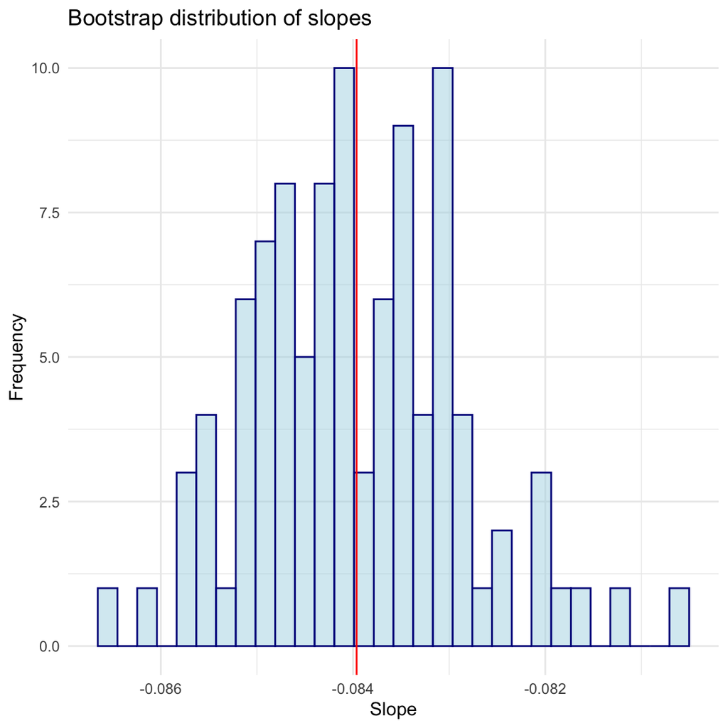

```r
ggplot(data = office_boot_slope, mapping = aes(x = stat)) +
  geom_histogram(color="darkblue", fill="lightblue", alpha = 0.5) +
  geom_vline(xintercept = mean(office_boot_slope$stat), color ="red")+
labs(title = "Bootstrap distribution of slopes", x = "Slope", y = "Frequency") +
  theme_minimal()
```

## Exercise 10

Calculate the confidence interval. A 95% confidence interval is bounded by the middle 95% of the bootstrap distribution. Fill in the values below.

```r
office_boot_slope %>%
  summarize(lower = quantile(stat, 0.025),
            upper = quantile(stat, 0.975))
```

```
## # A tibble: 1 × 2
##     lower   upper
##     <dbl>   <dbl>
## 1 -0.0858 -0.0818
```

## Exercise 11

Copy and paste your histogram code from exercise 3. Your task is to add on an additional 2 lines, one for the lower 95% bound and one for the higher 95% bound. Make the line dashed *and* a different color than your line you already have for the mean.

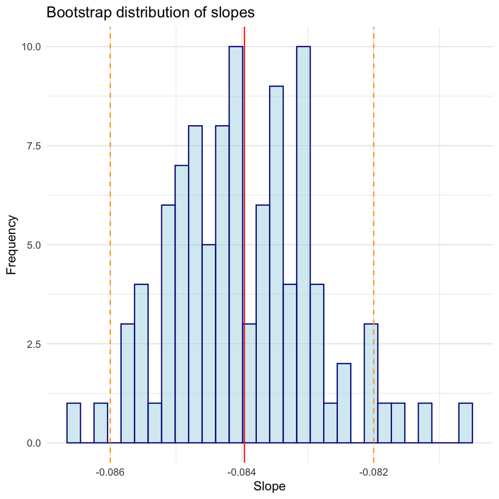

```r
ggplot(data = office_boot_slope, mapping = aes(x = stat)) +
  geom_histogram(color="darkblue", fill="lightblue", alpha = 0.5) +
  geom_vline(xintercept = mean(office_boot_slope$stat), color ="red") +
  geom_vline(xintercept = -0.086, color ="orange", linetype = "dashed") +
  geom_vline(xintercept = -0.082, color ="orange", linetype = "dashed") +
labs(title = "Bootstrap distribution of slopes", x = "Slope", y = "Frequency") +
  theme_minimal()
```

## Exercise 12

Your final task is to interpret what the 95% confidence bounds you calculated mean in the context of regression with The Office’s IMDB Ratings as the DV and season as the IV.